# Are the mean and the standard deviation in EVI2 explained by the previous leaf flush classification from Dexter et al. (2018)?

Marcio Baldissera Cure

2/20/2023

We performed linear models using R to test the *hypothesis* that *the previous leaf flush classification from Dexter et al. (2018) explains the mean and standard deviation (sd) in EVI2 time series*.

```r
model <- lm(sd_ndvi ~ Leaf_flush, data = completoRN)
```

```r
model1 <- lm(mean_ndvi ~ Leaf_flush, data = completoRN)
```

Models meet the assumption of homoscedasticity, normal distribution of residuals with a linear pattern and there is no influential observation (Figures 1 and 2).

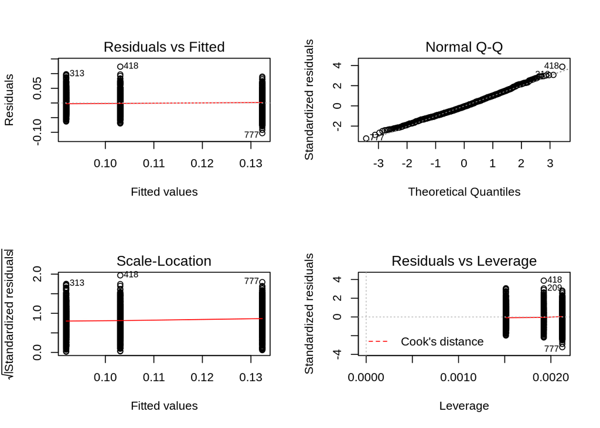

Figure 1: Diagnostic plot for the model testing the EVI2 standard deviation.

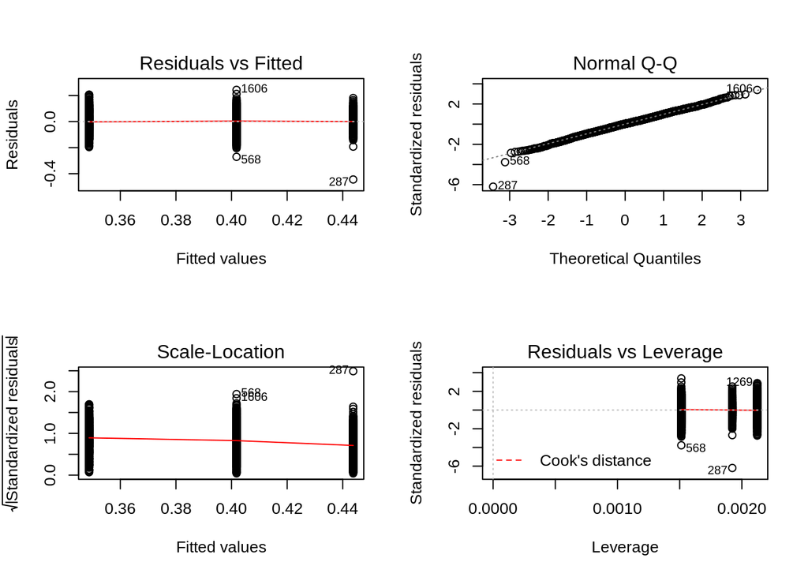

Figure 2: Diagnostic plot for the model testing the mean EVI2.

## Model Parameters

Despite the significance of both models (Tables 1 and 3), their adjusted R-squared are low (~ 0.2) (Tables 2 and 4) and may be other factors also influencing the mean and standard deviation in EVI2.

### EVI2 standard deviation

```
##                       term    estimate   std.error statistic      p.value
## 1:             (Intercept)  0.13233516 0.001471331  89.94249 0.000000e+00
## 2:     Leaf_flushEvergreen -0.02925245 0.002031166 -14.40180 2.205863e-44
## 3: Leaf_flushSemideciduous -0.04039746 0.001925453 -20.98076 8.066445e-87
##       conf.low   conf.high
## 1:  0.12944929  0.13522104
## 2: -0.03323638 -0.02526851
## 3: -0.04417405 -0.03662087
```

```
##    r.squared adj.r.squared      sigma statistic      p.value df   logLik
## 1: 0.2149119     0.2139597 0.03193161  225.7006 2.292032e-87  2 3347.165
##          AIC       BIC deviance df.residual nobs
## 1: -6686.331 -6664.692 1.681366        1649 1652
```

### Mean EVI2

```
##                       term   estimate   std.error statistic      p.value
## 1:             (Intercept) 0.34877819 0.003306896 105.46996 0.000000e+00
## 2:     Leaf_flushEvergreen 0.09497560 0.004565157  20.80446 1.494312e-85
## 3: Leaf_flushSemideciduous 0.05301596 0.004327559  12.25078 4.353033e-33
##      conf.low  conf.high
## 1: 0.34229204 0.35526435
## 2: 0.08602148 0.10392971
## 3: 0.04452787 0.06150405
```

```
##    r.squared adj.r.squared      sigma statistic      p.value df   logLik
## 1: 0.2082028     0.2072424 0.07176802   216.802 2.553995e-84  2 2009.305
##          AIC       BIC deviance df.residual nobs
## 1: -4010.611 -3988.972  8.49342        1649 1652
```

## Original data and fitted values from the model distributions

The statistical linear models used performed well and distributions of mean and standard deviations in EVI2 have the same pattern of the fitted values generated by the model (Figures 3-4).

### EVI2 standard deviation

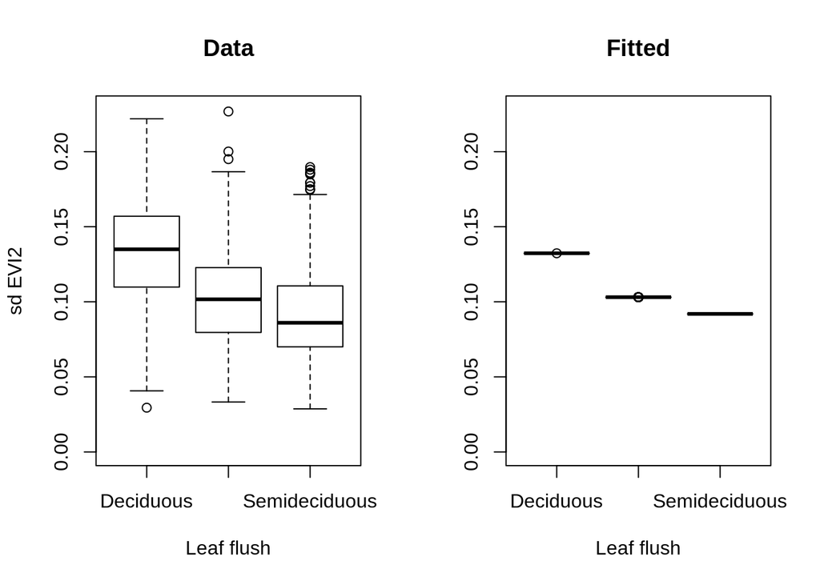

Figure 3: EVI2 standard deviation from the original data and from the values fitted by the model.

### Mean EVI2

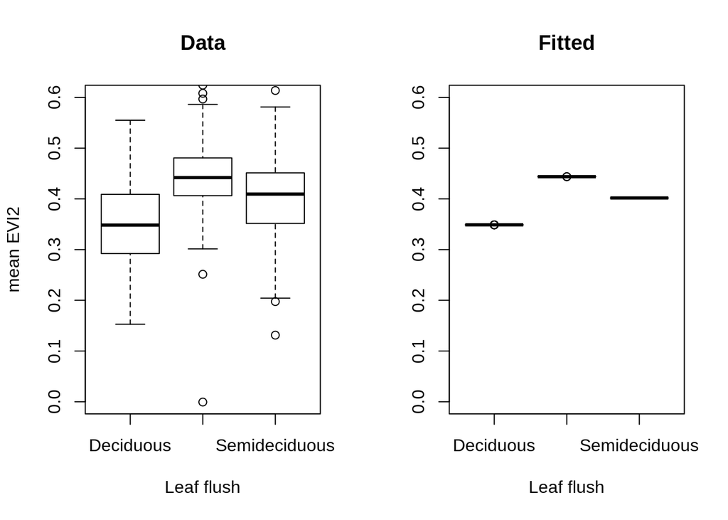

Figure 4: Mean EVI2 from the original data and from the values fitted by the model.

## Conclusion

We conclude that the leaf flush classification from Dexter et al. (2018) are able to explain EVI2 mean and the standard deviation in EVI2 for the sample points of the study.